# R Programming (Code Supplement)

This document contains code that is too long to display in the slides.

You should use this supplement to follow along and try executing the example code yourself.

# Variables and Namespaces

When you execute a statement like `x <- 5` in R, you are creating an **object** in memory which holds the numeric **value** 5 and is referenced by the **variable name** “x”.

If you later ask R to do something like `y <- x + 2`, it will search sequentially through a series of **namespaces** until it finds a variable called “x”. Namespaces can be thought of as collections of labels pointing to places in memory. You can use R’s `search()` command to examine the ordered list of namespaces that R will search in for variables.

```r
# Check the search path of namespaces
search()
```

```
## [1] ".GlobalEnv"        "package:stats"     "package:graphics"
## [4] "package:grDevices" "package:utils"     "package:datasets"
## [7] "package:methods"   "Autoloads"         "package:base"
```

```r
# use ls() to list the objects in one of those namespaces
ls("package:stats")
```

```
##   [1] "acf"                  "acf2AR"               "add.scope"
##   [4] "add1"                 "addmargins"           "aggregate"
##   [7] "aggregate.data.frame" "aggregate.ts"         "AIC"
##  [10] "alias"                "anova"                "ansari.test"
##  [13] "aov"                  "approx"               "approxfun"
##  [16] "ar"                   "ar.burg"              "ar.mle"
##  [19] "ar.ols"               "ar.yw"                "arima"
##  [22] "arima.sim"            "arima0"               "arima0.diag"
##  [25] "ARMAacf"              "ARMAtoMA"             "as.dendrogram"
##  [28] "as.dist"              "as.formula"           "as.hclust"
##  [31] "as.stepfun"           "as.ts"                "asOneSidedFormula"
##  [34] "ave"                  "bandwidth.kernel"     "bartlett.test"
##  [37] "BIC"                  "binom.test"           "binomial"
##  [40] "biplot"               "Box.test"             "bw.bcv"
##  [43] "bw.nrd"               "bw.nrd0"              "bw.SJ"
```

[output cut: 136 more lines]

```r
# use find() to check which namespace R is finding an object in
find("read.csv")
```

```
## [1] "package:utils"
```

# Dollarstore Calculator Math

Math in R looks very similar to how you might write it by hand.

```r
# Addition with "+"
4 + 5
```

```
## [1] 9
```

```r
# Subtraction with "-"
100 - 99
```

```
## [1] 1
```

```r
# Multiplication with "*"
4 * 5
```

```
## [1] 20
```

```r
# Division with "/"
15 / 3
```

```
## [1] 5
```

```r
# Exponentiation with "^"
2^3
```

```
## [1] 8
```

```r
# Order of Operations
4 * 5 + 5 / 5
```

```
## [1] 21
```

```r
# Control with parentheses
4 * (5 + 5) / 5
```

```
## [1] 8
```

# Data Structures

## Vectors

Because R was designed for statistical work, most of its operations are “vectorized” ([click here to learn more](https://www.cs.cornell.edu/courses/cs1112/2016sp/Exams/exam2/vectorizedCode.pdf)) vectorized.

```r
# Ordered sequence of integers
1:5
```

```
## [1] 1 2 3 4 5
```

```r
# Counting by 2s
seq(from = 0, to = 14, by = 2)
```

```
## [1]  0  2  4  6  8 10 12 14
```

```r
# Replicate the same values
rep(TRUE, 6)
```

```
## [1] TRUE TRUE TRUE TRUE TRUE TRUE
```

```r
# Concatenate multiple values with the "c" operator
c("all", "of", "the", "lights")
```

```
## [1] "all"    "of"     "the"    "lights"
```

```r
# Watch out! Mixing types will lead to silent coercion
c(1, TRUE, "hellos")
```

```
## [1] "1"      "TRUE"   "hellos"
```

```r
# Some functions, when applied over a vector, return a single value
is.numeric(rnorm(100))
```

```
## [1] TRUE
```

```r
# Others will return a vector of results
is.na(c(1, 5, 10, NA, 8))
```

```
## [1] FALSE FALSE FALSE  TRUE FALSE
```

```r
# Vectors can be named
batting_avg <- c(
  youkilis = 0.300
  , ortiz = 0.355
  , nixon = 0.285
)
print(batting_avg)
```

```
## youkilis    ortiz    nixon
##    0.300    0.355    0.285
```

```r
# You can combine two vectors with c()
x <- c("a", "b", "c")
y <- c("1", "2", "3")
c(x, y)
```

```
## [1] "a" "b" "c" "1" "2" "3"
```

## Lists

Vectors are the first multi-item data structure most R programmers learn. Soon, though, you may find yourself frustrated with the fact that they can only hold a single type. The `list` data structure is useful for cases where you want to hold objects of different types together in the same object.

| Capabilities | Vectors | Lists |
| --- | --- | --- |
| Optional use of named elements | ✔ | ✔ |
| Support math operations like mean() | ✔ |  |
| Hold multiple types |  | ✔ |
| Hold multiple objects |  | ✔ |

```r
# Create a list with list()
myList <- list(
  a = 1
  , b = rep(TRUE, 10)
  , x = c("shakezoola", "mic", "rulah")
)

# Examine it with str()
str(myList)
```

```
## List of 3
##  $ a: num 1
##  $ b: logi [1:10] TRUE TRUE TRUE TRUE TRUE TRUE ...
##  $ x: chr [1:3] "shakezoola" "mic" "rulah"
```

## Factors

Imagine that you want to build a model of the relationship between resource wealth and quality-of-life outcomes like life expectancy. You get some data from the Wold Bank, and the dataset you get includes a column called “region” with values like “Africa”, “European Union”, and “South America”. How can you use this variable in a model or for generating region-by-region summary stats?

This is where R’s **factor type** comes in.

```r
regions <- c("Africa", "European Union", "South America", "South America", "European Union")
region_fac <- as.factor(regions)

str(regions)
```

```
##  chr [1:5] "Africa" "European Union" "South America" "South America" ...
```

```r
str(region_fac)
```

```
##  Factor w/ 3 levels "Africa","European Union",..: 1 2 3 3 2
```

What does it mean for `region` to be a factor?

Essentially, a factor is a categorical variable. R uses a cool trick to save memory when storing factors…internally, R will convert factor values to integers and then keep around a single table that tells it, e.g., that 1 = “Africa”, 2 = “European Union”, etc..

```r
# Check it out! R has assigned integer values to the "region_fac" variable
as.integer(region_fac)
```

```
## [1] 1 2 3 3 2
```

```r
# But you can also access the character values if you want
as.character(region_fac)
```

```
## [1] "Africa"         "European Union" "South America"  "South America"
## [5] "European Union"
```

```r
# For more, see:
str(region_fac)
```

```
##  Factor w/ 3 levels "Africa","European Union",..: 1 2 3 3 2
```

```r
levels(region_fac)
```

```
## [1] "Africa"         "European Union" "South America"
```

## Data Frames

Vectors and lists are crucial data structures in R, but you may find that they’re difficult to work with for statistical tasks. It is now time to introduce a third foundational data structure: the data frame.

Data frames are tables of data. Each column of a data frame can be a different type, but all values within a column must be the same type.

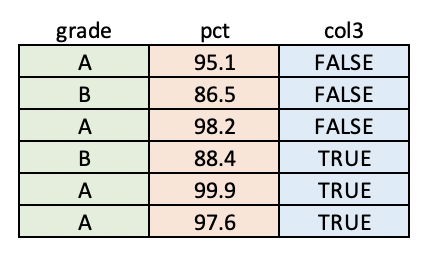

```r
# Create a data frame!
myDF <- data.frame(
    time_period    = c(1, 2, 3, 4, 5)
    , temperature  = c(25.6, 38.7, 31.4, 40.0, 29.20)
    , station      = c("A", "B", "A", "A", "B")
    , is_gov_owned = c(TRUE, FALSE, TRUE, TRUE, FALSE)
)

# Check out the structure of this thing
str(myDF)
```

```
## 'data.frame':    5 obs. of  4 variables:
##  $ time_period : num  1 2 3 4 5
##  $ temperature : num  25.6 38.7 31.4 40 29.2
##  $ station     : chr  "A" "B" "A" "A" ...
##  $ is_gov_owned: logi  TRUE FALSE TRUE TRUE FALSE
```

R comes with some sample data sets you can experiment with. Let’s load the `mtcars` data.frame and test out some new commands!

```r
# Load the mtcars data frame
data("mtcars")

# Check out its structure
str(mtcars)
```

```
## 'data.frame':    32 obs. of  11 variables:
##  $ mpg : num  21 21 22.8 21.4 18.7 18.1 14.3 24.4 22.8 19.2 ...
##  $ cyl : num  6 6 4 6 8 6 8 4 4 6 ...
##  $ disp: num  160 160 108 258 360 ...
##  $ hp  : num  110 110 93 110 175 105 245 62 95 123 ...
##  $ drat: num  3.9 3.9 3.85 3.08 3.15 2.76 3.21 3.69 3.92 3.92 ...
##  $ wt  : num  2.62 2.88 2.32 3.21 3.44 ...
##  $ qsec: num  16.5 17 18.6 19.4 17 ...
##  $ vs  : num  0 0 1 1 0 1 0 1 1 1 ...
##  $ am  : num  1 1 1 0 0 0 0 0 0 0 ...
##  $ gear: num  4 4 4 3 3 3 3 4 4 4 ...
##  $ carb: num  4 4 1 1 2 1 4 2 2 4 ...
```

```r
# View the top 10 rows
head(mtcars, n = 10)
```

```
##                    mpg cyl  disp  hp drat    wt  qsec vs am gear carb
## Mazda RX4         21.0   6 160.0 110 3.90 2.620 16.46  0  1    4    4
## Mazda RX4 Wag     21.0   6 160.0 110 3.90 2.875 17.02  0  1    4    4
## Datsun 710        22.8   4 108.0  93 3.85 2.320 18.61  1  1    4    1
## Hornet 4 Drive    21.4   6 258.0 110 3.08 3.215 19.44  1  0    3    1
## Hornet Sportabout 18.7   8 360.0 175 3.15 3.440 17.02  0  0    3    2
## Valiant           18.1   6 225.0 105 2.76 3.460 20.22  1  0    3    1
## Duster 360        14.3   8 360.0 245 3.21 3.570 15.84  0  0    3    4
## Merc 240D         24.4   4 146.7  62 3.69 3.190 20.00  1  0    4    2
## Merc 230          22.8   4 140.8  95 3.92 3.150 22.90  1  0    4    2
## Merc 280          19.2   6 167.6 123 3.92 3.440 18.30  1  0    4    4
```

```r
# View the bottom 10 rows
tail(mtcars, n = 10)
```

```
##                   mpg cyl  disp  hp drat    wt  qsec vs am gear carb
## AMC Javelin      15.2   8 304.0 150 3.15 3.435 17.30  0  0    3    2
## Camaro Z28       13.3   8 350.0 245 3.73 3.840 15.41  0  0    3    4
## Pontiac Firebird 19.2   8 400.0 175 3.08 3.845 17.05  0  0    3    2
## Fiat X1-9        27.3   4  79.0  66 4.08 1.935 18.90  1  1    4    1
## Porsche 914-2    26.0   4 120.3  91 4.43 2.140 16.70  0  1    5    2
## Lotus Europa     30.4   4  95.1 113 3.77 1.513 16.90  1  1    5    2
## Ford Pantera L   15.8   8 351.0 264 4.22 3.170 14.50  0  1    5    4
## Ferrari Dino     19.7   6 145.0 175 3.62 2.770 15.50  0  1    5    6
## Maserati Bora    15.0   8 301.0 335 3.54 3.570 14.60  0  1    5    8
## Volvo 142E       21.4   4 121.0 109 4.11 2.780 18.60  1  1    4    2
```

# Logical Operators

Often in your code, you’ll want to do/not do something or select / not select some data based on a logical condition (a statement that evaluates to TRUE or FALSE).

Here are some examples of how to construct these statements in R.

```r
# "and" logic is expressed with "&"
TRUE & TRUE   # TRUE
```

```
## [1] TRUE
```

```r
TRUE & FALSE  # FALSE
```

```
## [1] FALSE
```

```r
FALSE & FALSE # FALSE
```

```
## [1] FALSE
```

```r
-5 < 5 & 3 > 2 # TRUE
```

```
## [1] TRUE
```

```r
# "or" logic is expressed with "|"
TRUE | TRUE    # TRUE
```

```
## [1] TRUE
```

```r
TRUE | FALSE   # TRUE
```

```
## [1] TRUE
```

```r
FALSE | FALSE  # FALSE
```

```
## [1] FALSE
```

```r
3 < 8 | 8 > 19 # TRUE
```

```
## [1] TRUE
```

The most common operators used to generate logicals are `>`, `<`, `==`, and `!=`

```r
# "equality" logic is specified with "=="
3 == 3   # TRUE
```

```
## [1] TRUE
```

```r
4 == 4.1 # FALSE
```

```
## [1] FALSE
```

```r
# "not" logic is specified with !. In a special case, != signifies "not equal"
!TRUE            # FALSE
```

```
## [1] FALSE
```

```r
!FALSE           # TRUE
```

```
## [1] TRUE
```

```r
! (TRUE | FALSE) # FALSE
```

```
## [1] FALSE
```

```r
4 != 5           # TRUE
```

```
## [1] TRUE
```

```r
# "greater than" and "less than" logic are specified in the way you might expect
5 < 5  # FALSE
```

```
## [1] FALSE
```

```r
6 <= 6 # TRUE
```

```
## [1] TRUE
```

```r
4 > 2  # TRUE
```

```
## [1] TRUE
```

```r
3 >= 3 # TRUE
```

```
## [1] TRUE
```

You can use vectors of logicals (TRUE and FALSE) to subset other objects. As a general rule, when you put a vector on the left-hand side of a logical condition like `==` or `>`, you will get back a vector as a result.

```r
vehicleSizes <- c(1, 5, 5, 2, 4)

# Create a logical index. Note that we get a VECTOR of logicals back
bigCarIndex <- vehicleSizes > 4
print(bigCarIndex)
```

```
## [1] FALSE  TRUE  TRUE FALSE FALSE
```

```r
# Taking the SUM of a logical vector tells you the number of TRUEs.
sum(bigCarIndex)
```

```
## [1] 2
```

```r
# Taking the MEAN of a logical vector tells you the proportion of TRUEs
mean(bigCarIndex)
```

```
## [1] 0.4
```

# Subsetting

## Subsetting Vectors

**Subsetting** is the act of retrieving a portion of an object, usually based on some logical condition (e.g. “all elements greater than 5”). In R, this is done with the `[` operator.

```r
myVec <- c(
    var1 = 10
    , var2 = 15
    , var3 = 20
    , av4 = 6
)

# "the first element"
myVec[1]
```

```
## var1
##   10
```

```r
# "second to fourth element"
myVec[c(2, 3, 4)]
```

```
## var2 var3  av4
##   15   20    6
```

```r
# "second to fourth elements"
myVec[2:4]
```

```
## var2 var3  av4
##   15   20    6
```

```r
# "the element named var3"
myVec["var3"]
```

```
## var3
##   20
```

```r
# "the elements named var1 and var3"
myVec[c("var1", "var3")]
```

```
## var1 var3
##   10   20
```

```r
# "third element, then the fourth one repeated twice"
myVec[c(3, 4, 4)]
```

```
## var3  av4  av4
##   20    6    6
```

## Subsetting Lists

Lists, arbitrary collections of (potentially heterogeneous) R objects, are subsetted a bit differently than vectors. You have a few options:

- `[` = guaranteed to return a list
- `[[` = get back an object in its natural form (whatever it would look like if it wasn’t in the list)
- `$` = similar to `[[`, but only accepts element names

```r
# Set up a sample list object
someList <- list(
    country = "DEU"
    , region  = "EU"
    , econ_stats = list(
        gdp_growth = 1.5
        , rm10y    = 2.75
        , DAXmonthly = c(1000, 1100, 1050, 1200, 1500)
    )
)

# Examine the list structure
str(someList)
```

```
## List of 3
##  $ country   : chr "DEU"
##  $ region    : chr "EU"
##  $ econ_stats:List of 3
##   ..$ gdp_growth: num 1.5
##   ..$ rm10y     : num 2.75
##   ..$ DAXmonthly: num [1:5] 1000 1100 1050 1200 1500
```

```r
# Grab the country name
country1 <- someList[["country"]]
country2 <- someList$country

class(country1)
```

```
## [1] "character"
```

```r
class(country2)
```

```
## [1] "character"
```

```r
identical(country1, country2)
```

```
## [1] TRUE
```

```r
# Grab the economic stats as a list within a list
germanyStats <- someList["econ_stats"]
class(germanyStats)
```

```
## [1] "list"
```

```r
# Grab the numeric vector of stock prices
daxPrices <- someList$econ_stats$DAXmonthly
class(daxPrices)
```

```
## [1] "numeric"
```

```r
# Another way to parse down the list for stock prices
someList[["econ_stats"]][["DAXmonthly"]]
```

```
## [1] 1000 1100 1050 1200 1500
```

## Subsetting Data Frames

Data frames are the workhorse data structure of statistics in R.

To practice subsetting data frames, try modifying the examples below.

```r
# Create a data frame
someDF <- data.frame(
    conference  = c("Big East", "Big Ten", "Big East", "ACC", "SEC")
    , school_name = c("Villanova", "Minnesota", "Marquette", "Duke", "LSU")
    , wins        = c(18, 14, 19, 24, 12)
    , ppg         = c(71.5, 45.8, 66.9, 83.4, 58.7)
)

# Grab the wins column (NOTE: will give you back a vector)
someDF[, "wins"]
```

```
## [1] 18 14 19 24 12
```

```r
someDF[["wins"]]
```

```
## [1] 18 14 19 24 12
```

```r
# Grab conference and wins columns
someDF[, c("conference", "wins")]
```

```
##   conference wins
## 1   Big East   18
## 2    Big Ten   14
## 3   Big East   19
## 4        ACC   24
## 5        SEC   12
```

```r
# Grab the first 3 rows and the two numeric columns
someDF[1:3, c("wins", "ppg")]
```

```
##   wins  ppg
## 1   18 71.5
## 2   14 45.8
## 3   19 66.9
```

## Using Logical Vectors

So far, we’ve seen how to subset R objects using numeric indices and named elements. These are useful approaches, but both require you to know something about the contents of the object you’re working with.

Using these methods (especially numeric indices like saying *“give me columns 2-4”*) can make your code confusing and hard for others to reason about. Wherever possible, I strongly recommend using logical vectors for subsetting. This makes your code easier to read and more likely to be correct if the data changes.

```r
# Some data frame
playerDF <- data.frame(
    playerName   = c("Rajon Rondo", "Paul Pierce", "Kevin Garnett", "Ray Allen", "Big Baby")
    , position   = c("PG", "SF", "PF", "SG", "C")
    , apg        = c(14.2, 3.5, 4.6, 5.0, 0.7)
    , ppg        = c(4.8, 31.0, 24.6, 33.2, 12.3)
    , fg_percent = c(-0.062, 0.48, 0.63, 0.80, 0.51)
)

# "Give me a data frame with all Rondo and KG's stats"
nameIndex <- playerDF$playerName %in% c("Rajon Rondo", "Kevin Garnett")
nameIndex
```

```
## [1]  TRUE FALSE  TRUE FALSE FALSE
```

```r
class(nameIndex)
```

```
## [1] "logical"
```

```r
playerDF[nameIndex, ]
```

```
##      playerName position  apg  ppg fg_percent
## 1   Rajon Rondo       PG 14.2  4.8     -0.062
## 3 Kevin Garnett       PF  4.6 24.6      0.630
```

```r
# "Give me apg for players who averaged more than 20 ppg"
playerDF[playerDF$ppg > 20, c("playerName", "apg")]
```

```
##      playerName apg
## 2   Paul Pierce 3.5
## 3 Kevin Garnett 4.6
## 4     Ray Allen 5.0
```

```r
# "Give me stats for all the guards""
guardIndex <- grepl("G", playerDF$position, fixed = TRUE)
print(guardIndex)
```

```
## [1]  TRUE FALSE FALSE  TRUE FALSE
```

```r
playerDF[grepl("G", playerDF$position, fixed = TRUE)]
```

```
##      playerName  ppg
## 1   Rajon Rondo  4.8
## 2   Paul Pierce 31.0
## 3 Kevin Garnett 24.6
## 4     Ray Allen 33.2
## 5      Big Baby 12.3
```

```r
# "Give me stats for players who were guards OR show above 50% from the field"
playerDF[grepl("G", playerDF$position, fixed = TRUE) | playerDF$fg_percent > 0.5, ]
```

```
##      playerName position  apg  ppg fg_percent
## 1   Rajon Rondo       PG 14.2  4.8     -0.062
## 3 Kevin Garnett       PF  4.6 24.6      0.630
## 4     Ray Allen       SG  5.0 33.2      0.800
## 5      Big Baby        C  0.7 12.3      0.510
```

# Controlling Program Flow

## If-Else

Soon after you start writing code (in any language), you’ll inevitably find yourself saying “I only want to do this thing if certain conditions are met”. This type of logic is expressed using if-else syntax

```r
DAY <- "SATURDAY"
print(DAY)
```

```
## [1] "SATURDAY"
```

```r
# If it's Monday, print 2 messages. Otherwise, print 1
if (DAY == "MONDAY") {
    print("It is Monday.")
    print("I love Monday!")
} else {
    print("I wish it were Monday.")
}
```

```
## [1] "I wish it were Monday."
```

What if you want to express more than two possible outcomes? For this, we could use R’s `else if` construct to nest conditions. Note that conditional blocks can have any number of “else if” statements, but only one “else” block.

```r
# Try to think through what this will do before you run it yourself:
if (4 > 5) {
    print("3")
} else if (6 <= (5 / 10)) {
    print("1")
} else if (4 + 4 + 4 == 12.0001) {
    print("4")
} else {
    print("2")
}
```

```
## [1] "2"
```

## For Loops

One of the most powerful characteristics of general purpose programming languages is their ability to automate repetitive tasks. When you know that you want to do something a fixed number of times (say, squaring each item in a vector), you can use a `for` loop.

```r
# Create a vector
x <- c(1, 4, 6)

# Print the square of each element one at a time
print(1^2)
```

```
## [1] 1
```

```r
print(4^2)
```

```
## [1] 16
```

```r
print(6^2)
```

```
## [1] 36
```

```r
# BETTER: Loop over the vector and print the square of each element
for (some_number in x) {
    print(some_number^2)
}
```

```
## [1] 1
## [1] 16
## [1] 36
```

## While Loops

`for` loops are suitable for many applications, but they can be too restrictive in some cases.

Here is the `for` loop implementation:

```r
movies <- c(
    "ace ventura"
    , "apocalypse now"
    , "return of the jedi"
    , "v for vendetta"
    , "zoolander"
)
MOVIE_TO_SEARCH_FOR <- "apocalypse now"

# Naive for loop implementation
i <- 1
for (movie in movies) {
    if (movie == MOVIE_TO_SEARCH_FOR) {
        print(paste0(i, ": found it!"))
    } else {
        print(paste0(i, ": not found"))
    }
    i <- i + 1
}
```

```
## [1] "1: not found"
## [1] "2: found it!"
## [1] "3: not found"
## [1] "4: not found"
## [1] "5: not found"
```

And here is the `while` loop implementation. Notice that this one stops checking once it finds what it wants. In this case, it’s more efficient to use a `while` loop to solve this problem.

```r
movies <- c(
    "ace ventura"
    , "apocalypse now"
    , "return of the jedi"
    , "v for vendetta"
    , "zoolander"
)
MOVIE_TO_SEARCH_FOR <- "apocalypse now"

# Faster while loop implementation
KEEP_SEARCHING <- TRUE
i <- 1
while (KEEP_SEARCHING) {

    # Check this element
    if (movies[i] == MOVIE_TO_SEARCH_FOR) {
        print(paste0(i, ": found it!"))
        KEEP_SEARCHING <- FALSE
    } else {
        # if it wasn't found, increment the counter
        print(paste0(i, ": not found"))
        i <- i + 1
    }

    # If we've reached the end, stop searching
    if (i > length(movies)) {
        print("Done searching. This movie isn't in the list")
        KEEP_SEARCHING <- FALSE
    }
}
```

```
## [1] "1: not found"
## [1] "2: found it!"
```

# Functions

R is a [functional programming language](https://adv-r.hadley.nz/functions.html). To write powerful, concise code, you’ll want to learn how to use and create functions.

> *“If you find yourself copying and pasting the same code more than twice, it’s time to write a function.”*
> - Hadley Wickham

```r
# Function to return only the numbers smaller than 10
nums <- c(1, 3, 4, 8, 13, 24)

getLittleNumbers <- function(some_numbahs) {
    lil_ones <- some_numbahs[some_numbahs < 10]
    return(lil_ones)
}

getLittleNumbers(nums)
```

```
## [1] 1 3 4 8
```

## Positional and Keyword Arguments

When you call a function with arguments in R, you can provide those arguments two ways:

- “positional” = based on the order
- “keyword” = matching a specific argument by name

```r
someFunction <- function(x, y, z) {
  print(paste0("x: ", x))
  print(paste0("y: ", y))
  print(paste0("z: ", z))
}
```

If you don’t use the `=` sign in the function call, all argument values are matched positionally. The first value is assigned to the first argument, the second to the second, and so on.

```r
someFunction(4, 8, 10)
```

```
## [1] "x: 4"
## [1] "y: 8"
## [1] "z: 10"
```

If you pass all keyword arguments, you can pass them in any order. All of the function calls below have the same result.

```r
someFunction(x = 1, y = -1, z = 3)
```

```
## [1] "x: 1"
## [1] "y: -1"
## [1] "z: 3"
```

```r
someFunction(x = 1, z = 3, y = -1)
```

```
## [1] "x: 1"
## [1] "y: -1"
## [1] "z: 3"
```

```r
someFunction(z = 3, y = -1, x = 1)
```

```
## [1] "x: 1"
## [1] "y: -1"
## [1] "z: 3"
```

If you pass a mix of positional and keyword, all of the keyword arguments are matched first. Once they’ve all been matched, the positional values are assigned to the remaining unmatched arguments in order.

```r
someFunction(10, 100, x = -5)
```

```
## [1] "x: -5"
## [1] "y: 10"
## [1] "z: 100"
```

## Required Arguments

R functions take 0 or more arguments…basically named variables that the function uses to do it work

Take a look at `?sqrt`. You’ll see that it takes one argument, named `x`. You can pass any vector of numeric values to this argument and `sqrt()` will return the square root of each element

In this case, we’d say `x` is a *required argument* of `sqrt()`.

```r
# Take the square root of a vector of numbers
sqrt(x = c(1, 4, 9, 16, 25))
```

```
## [1] 1 2 3 4 5
```

```r
# Note that calling this function without the argument will throw an error!
sqrt()
```

```
## Error in `sqrt()`:
## ! 0 arguments passed to 'sqrt' which requires 1
```

## Default Argument Values

For more complicated functions, passing values to each argument can be tedious.

To handle this, R allows function authors to specify *default values*. These are values that certain arguments will take automatically unless you decide to overwrite them

Example: look at `?rnorm`. You’ll see that this function’s signature reads `rnorm(n, mean = 0, sd = 1)`. That means that, for example, if you do not pass an argument for `mean`, it will *default* to `0`.

```r
# 100 random draws from a normal distribution w/ mean 0 and standard deviation 1
rand_nums <- rnorm(n = 100)

# 100 random draws from a normal distribution w/ mean 4.5 and standard deviation 1
rand_nums <- rnorm(n = 100, mean = 4.5)
```

## Functions That Return Stuff

As you’ve seen in previous examples, the R special word `return` tells a function to “give back” some value. When you execute an expression like `x <- someFunction()`, that function’s return value (an R object) is stored a variable called “x”.

Unlike in some other programming languages, R allows you to use multiple `return` values inside the body of a function. The first time that the code inside the function reaches a `return` value, it will pass that value back out of the function and immediately stop executing the function.

```r
# simple function + print debugging
simpFunction <- function(n) {
    print("first print")
    if (n > 5) {
      return(TRUE)
    }

    print("second print")
    if (n < 5) {
      return(FALSE)
    }

    print("third print")
    return("TRALSE")
}

simpFunction(100)
```

```
## [1] "first print"
```

```
## [1] TRUE
```

```r
simpFunction(5)
```

```
## [1] "first print"
## [1] "second print"
## [1] "third print"
```

```
## [1] "TRALSE"
```

## Functions That Return Nothing

Not all functions have to return something! Sometimes you may want to create a function that just has some side effect like creating a plot, writing to a file, or print to the console.

These are called “null functions” and they’re common in scripting languages like R. By default, these functions return the R special value `NULL`.

```r
printSentence <- function(theSentence) {
    words <- strsplit(
      x = theSentence
      , split = " "
      , fixed = TRUE
    )
    for (word in words) {
        print(word)
    }
}

# Assigning to an object is irrelevant...this function doesn't return anything
x <- printSentence("Hip means to know, it's a form of intelligence")
```

```
## [1] "Hip"          "means"        "to"           "know,"        "it's"
## [6] "a"            "form"         "of"           "intelligence"
```

```r
x
```

[output not shown]

## Scoping

Remember when we talked about namespaces and how R searches for objects? It’s time to extend that logic to functions…which is where things get a bit weird and hard to understand.

R uses a search technique called lexical scoping.

Let’s define a function that takes a single input, named `y`.

```r
someFunc <- function(y) {
    return(x^2)
}
```

When you try to call this function in a clean environment, it throws an error. This is because the code inside the function is looking for something called `x`.

```r
someFunc(y = 5)

### Error in someFunc(y = 5) : object 'x' not found
```

If you define `x` in the global environment and try again, the function won’t throw an error…but does its result make sense?

```r
x <- 4
someFunc(y = 5)
```

```
## [1] 16
```

What happened here? When R ran the statement `x ^ 2` inside the function `someFunc()`, it went searching for the value of `x`. It first looked around in the function’s local environment, but all it found there was a `y` (the argument you passed in). Next, it went “up a level” in to the global environment. It found `x` there and used that.

In practice, this is very dangerous. Functions should always be self-contained, which means they should only reference objects passed in to them or made available via libraries. Relying on data in the global environment can lead to strange outcomes. Notice that now, the output of `someFunc()` is the same no matter what we pass it!

```r
someFunc(1)
```

```
## [1] 16
```

```r
someFunc(8)
```

```
## [1] 16
```

```r
someFunc(20)
```

```
## [1] 16
```

It would be better to re-write the function to take in `x`.

```r
someFunc <- function(x) {
    return(x^2)
}
```

With this re-write, now the function will use the `x` in its local environment (the one that was passed in), and not look at the one in the global environment.

```r
someFunc(x = 5)
```

```
## [1] 25
```

Because the function’s local environment is its own independent thing, calling the function `someFunc()` does not alter the value of `x` in the global environment.

```r
print(x)
```

```
## [1] 4
```

```r
someFunc(x = 10)
```

```
## [1] 100
```

```r
print(x)
```

```
## [1] 4
```

## Looping with lapply

R’s `*apply` family of functions are a bit difficult to understand at first, but soon you’ll come to love them. They make your code more expressive, flexible, and parallelizable (more on that final point later). One of the most popular is `lapply()` (“list apply”), which loops over a thing (e.g. vector, list) and returns a 1-level list. Let’s try it out:

```r
# Create a list
studentList <- list(
  wale = c(80, 90, 100)
  , talib = c(95, 85, 99)
  , common = c(100, 100, 99)
)

# Better way with lapply
grades <- lapply(studentList, mean)
str(grades)
```

```
## List of 3
##  $ wale  : num 90
##  $ talib : num 93
##  $ common: num 99.7
```

## Looping with sapply

You’ve seen how to loop over a vector/list and get back a list of function results. This may not be appropriate for some settings. Remember that you cannot execute statistical operations like `mean()` over a list. For that, we’d probably prefer to have a *vector* of results. This is where R’s `sapply()` (“simplified apply”) comes in. `sapply()` works the same way that `lapply()` does but returns a vector. Try it for yourself:

```r
# Get some data
data("ChickWeight")
weights <- ChickWeight$weight

# Loop over and encode "above mean" and "below mean"
the_mean <- mean(weights)
meanCheck <- function(val, ref_mean) {
    if (val > ref_mean) {
        return("above mean")
    }
    if (val < ref_mean) {
        return("below mean")
    }
    return("equal to the mean")
}
check_vec <- sapply(
    X = weights
    , FUN = function(x) {
        meanCheck(val = x, ref_mean = the_mean)
    }
)
str(check_vec)
```

```
##  chr [1:578] "below mean" "below mean" "below mean" "below mean" ...
```

## Looping with apply

When analyzing real-world datasets, you may want to use the same looping convention we’ve been discussing, but apply it over many items and the get some summary (such as the median) of the results. This is where R’s `apply()` function comes in!

`apply()` allows you to loop over the rows or columns of a data frame and execute an arbitrary function. The code below holds some examples of what can be accomplished with `apply()`.

```r
# Get some data
data("ChickWeight")

# Calculate column-wise range
cwRanges <- apply(
    X = ChickWeight
    , MARGIN = 2
    , FUN = function(x) {
        range(as.numeric(x))
    }
)

# Calculate row-wise range
rwRanges <- apply(
    X = ChickWeight
    , MARGIN = 1
    , FUN = function(blah) {
        range(as.numeric(blah))
    }
)
str(rwRanges)
```

```
##  num [1:2, 1:578] 0 42 1 51 1 59 1 64 1 76 ...
##  - attr(*, "dimnames")=List of 2
##   ..$ : NULL
##   ..$ : chr [1:578] "1" "2" "3" "4" ...
```

# Using External Packages

This example shows some interesting data visualizations you can make using `{data.table}`, `{dygraphs}`, and `{quantmod}`.

Install these packages (this only needs to be done once):

```r
install.packages(c("data.table", "dygraphs", "quantmod"))
```

Then run the following:

```r
# Load dependencies
library(data.table)
library(dygraphs)
library(quantmod)

# Get data
cpiData <- quantmod::getSymbols(
    Symbols = "CPIAUCSL"
    , src = "FRED"
    , auto.assign = FALSE
)["1947-01-01/2023-11-01"]

# Plot it!
dygraphs::dygraph(
    data = cpiData
    , main = "U.S. CPI"
    , xlab = "date"
    , ylab = "Index (1982-1984 = 100)"
    , elementId = "plot"
) %>%
    dygraphs::dyRangeSelector()
```

[interactive chart not shown]

## Telling R which package to use

The use of `::` in the example above is important. That tells R exactly which package namespace to look in for a given function.

Consider this example:

```r
library(data.table)

find("fread")
```

```
## [1] "package:data.table"
```

```r
fread <- function() {
    print("using my custom fread()")
}

find("fread")
```

```
## [1] ".GlobalEnv"         "package:data.table"
```

```r
fread
```

```
## function ()
## {
##     print("using my custom fread()")
## }
```

The first `find("fread")` there finds the one from `{data.table}`. The `fread()` custom function defined later then takes precedence over that one that was loaded earlier.

To ensure that your code isn’t dependent on the order that libraries are loaded, you should always use `::` when referencing functions from external packages.

Like this:

```r
data.table::fread(...)
```

## Sourcing Helper Functions

In the examples so far, I’ve been defining functions and using them in the same script. As your projects grow in complexity, you will find this really tedious and hard to keep track of.

An alternative that many R programmers turn to is defining one or more `helperfuns.R` scripts to store custom functions and then using `source()` at the top of their run scripts to make those functions available in the main program.

Let’s create two scripts.

**script 1: helperfuns.R**

```r
# Define some arbitrary custom function
myFunction <- function(n) {
    if (n <= 5) {
        return(n^2)
    } else {
        return(n^3)
    }
}
```

**script 2: run_script.R**

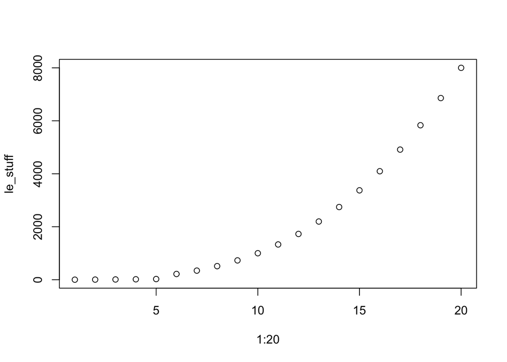

```r
# uncomment the line below to source in the helper functions file
#source("helperfuns.R")

# Apply that function over some data
le_stuff <- sapply(1:20, myFunction)

# Plot the result
plot(x = 1:20, y = le_stuff)
```

# Debugging

## Print Debugging

Writing code involves a never-ending process of trying things, fixing errors, trying other things, fixing new errors, etc. The process of identifying and fixing issues is called **debugging**.

The simplest way to debug an issue in your code is to use **print debugging**. This approach involves forming expectations about the state of the objects in your environment at each point in your code, then printing those states at each point to find where things broke.

```r
# This function is supposed to sum all the numbers in a vector that are greater than 10
# but it's breaking with a weird error. Let's use print debugging to dig into it
sumBigNums <- function(aVector) {
    running_sum <- 0
    for (num in aVector) {
        if (num >= 10) {
            running_sum <- running_sum + num
        }
    }
    return(running_sum)
}

# This should return 45...hmmmmmm
some_vector <- c(11, 20, 5, 9.5, 10, 14)
sumBigNums(some_vector)
```

```
## [1] 55
```

```r
# Let's refactor this function (change the code) and print the status at each stage
sumBigNums <- function(aVector) {
    running_sum <- 0
    for (num in aVector) {
        # Grab the sum before we hit this number
        sum_before <- running_sum

        # If the number if greater than 10, increase the sum
        if (num >= 10) {
            running_sum <- running_sum + num
        }

        # print new state of the environment
        msg <- paste0("num: ", num, " | before: ", sum_before, " | after: ", running_sum)
        print(msg)
    }
    return(running_sum)
}

# Run the code again and look at the output...it looks like we added the number
# 10 to the count even though it isn't greater than 10! We need to change
# the code to say "num > 10", not ">="
sumBigNums(some_vector)
```

```
## [1] "num: 11 | before: 0 | after: 11"
## [1] "num: 20 | before: 11 | after: 31"
## [1] "num: 5 | before: 31 | after: 31"
## [1] "num: 9.5 | before: 31 | after: 31"
## [1] "num: 10 | before: 31 | after: 41"
## [1] "num: 14 | before: 41 | after: 55"
```

```
## [1] 55
```

# Working with Files

## File Paths

Whenever you find yourself reading data into R or writing data out of it, you will need to work with file paths. File paths are just addresses on your computer’s file system.

There are 2 types of file paths:

- **relative**: expressed in relation to the current working directory (e.g. `datasets/data.csv`)
- **absolute**: full address (e.g. `/Users/fnourzad/research/datasets/data.csv`)

All relative paths in R are relative to your **working directory**, a single location that you can set and reset any time in your session.

```r
# Check and then change the current working directory
print(getwd())
sandbox_repo <- file.path(getwd(), "repos", "sandbox")
setwd(sandbox_repo)

# Reference a file with a full path
myDF <- read.csv(
    file = file.path(
        sandbox_repo
        , "data"
        , "some_data.csv"
    )
)

# Reference a file with a relative path
myDF <- read.csv(file = "./data/some_data.csv")
```

R provides a few other utilities for working with file paths and directory structures.

- `file.path()`: create a filepath from multiple parts
- `file.exists()`: returns `TRUE` is a file exists and `FALSE` if it doesn’t
- `list.files()`: get a character vector with names of all files found in a directory
- `dir.exists()`: returns `TRUE` is a directory exists and `FALSE` if it doesn’t
- `dir.create()`: create a new directory

```r
# List all the files in some directory and put the list in a vector
docs_dir <- file.path(
    getwd()
    , "some_folder"
    , "docs"
)
theFiles <- list.files(path = docs_dir)

# Create a directory if it doesn't exist
slide_dir <- file.path(docs_dir, "slides")
if (!dir.exists(slide_dir)) {
    dir.create(slide_dir)
}

# Check if a file exists
report_file <- file.path(docs_dir, "report.xlsx")
myFileExists <- file.exists(report_file)
```

## Downloading files from the internet

To download files hosted on the internet, you can use `download.file()`.

```r
download.file(
  url = "https://raw.githubusercontent.com/jameslamb/intro-to-r/main/sample-data/iris.csv"
  , destfile = "iris.csv"
)
```

## CSV

CSV stands for “comma-separated values”. This format is a really common to share small, tabular datasets because it is just a text file, and can be ready by many different types of programs. R has several options for reading this type of file.

- `read.csv()`: base R function for reading CSVs into a `data.frame`
- `data.table::fread()`: super-fast CSV reader that creates a special type of `data.frame` called a `data.table`
- `read.delim()`: similar to `read.csv()`, but can read files with any delimiter
- `readr::read_csv()`: CSV reader from RStudio

A CSV is just a plaintext file where the first row is column names separated by columns and each following row is an observation with columns separated by commas.

```
date,open,close
01-01-2012,10.5,8.9
01-02-2012,8.9,10.3
```

To begin this example, download the example file from the course repository.

```r
iris_url <- "https://raw.githubusercontent.com/jameslamb/intro-to-r/main/sample-data/iris.csv"
iris_file <- "iris.csv"
download.file(
  url = iris_url
  , destfile = iris_file
)
```

Then read it in with `read.csv()` and inspect it with `head()`.

```r
irisDF <- read.csv(
  file = iris_file
  , header = TRUE
  , row.names = 1
)
print(head(irisDF))
```

```
##   Sepal.Length Sepal.Width Petal.Length Petal.Width Species
## 1          5.1         3.5          1.4         0.2  setosa
## 2          4.9         3.0          1.4         0.2  setosa
## 3          4.7         3.2          1.3         0.2  setosa
## 4          4.6         3.1          1.5         0.2  setosa
## 5          5.0         3.6          1.4         0.2  setosa
## 6          5.4         3.9          1.7         0.4  setosa
```

This function can also read CSV data directly from files on the internet.

```r
irisDF <- read.csv(
  file = iris_url
  , header = TRUE
  , row.names = 1
)
print(head(irisDF))
```

```
##   Sepal.Length Sepal.Width Petal.Length Petal.Width Species
## 1          5.1         3.5          1.4         0.2  setosa
## 2          4.9         3.0          1.4         0.2  setosa
## 3          4.7         3.2          1.3         0.2  setosa
## 4          4.6         3.1          1.5         0.2  setosa
## 5          5.0         3.6          1.4         0.2  setosa
## 6          5.4         3.9          1.7         0.4  setosa
```

## Excel

Microsoft Excel is widely used for curating and sharing datasets.

You’ll get data from the internet, your colleagues, clients, etc. in Excel format and may want to work with it in R. There are a few packages for doing this, but in this course we’ll focus on [openxlsx](https://cran.r-project.org/web/packages/openxlsx/openxlsx.pdf).

NOTE: This package requires certain Java components that you may not have on your machine. If you run into issues, I recommend 1) installing an updated version of [JRE](https://www.oracle.com/technetwork/java/javase/downloads/jre8-downloads-2133155.html) or 2) exploring other packages like [xlsx](https://cran.r-project.org/web/packages/xlsx/xlsx.pdf) or [readxl](https://cran.r-project.org/web/packages/readxl/readxl.pdf).

To begin this example, download the example file from the course repository.

```r
gdp_url <- "https://raw.githubusercontent.com/jameslamb/intro-to-r/main/sample-data/gdp.xlsx"
gdp_file <- "gdp.xlsx"
download.file(
  url = gdp_url
  , destfile = gdp_file
)
```

Then read it in with `openxlsx::read.xlsx()` and view it with `head()`.

```r
library(openxlsx)
gdpDF <- openxlsx::read.xlsx(
    xlsxFile = gdp_file
    , detectDates = TRUE
)
print(head(gdpDF))
```

```
##   observation_date REALGDP_YOY
## 1       1947-04-01        -1.0
## 2       1947-07-01        -0.8
## 3       1947-10-01         6.4
## 4       1948-01-01         6.2
## 5       1948-04-01         6.8
## 6       1948-07-01         2.3
```

This function can also read Excel data directly from files on the internet.

```r
library(openxlsx)
gdpDF <- openxlsx::read.xlsx(
    xlsxFile = gdp_url
    , detectDates = TRUE
)
print(head(gdpDF))
```

```
##   observation_date REALGDP_YOY
## 1       1947-04-01        -1.0
## 2       1947-07-01        -0.8
## 3       1947-10-01         6.4
## 4       1948-01-01         6.2
## 5       1948-04-01         6.8
## 6       1948-07-01         2.3
```

You can also use this package to write Excel files. You can do really complicated stuff (like conditional formatting, named ranges, and live formulas) from inside of R. It’s tough to set up at first, but can be VERY useful if you find yourself spending a lot of time running routine reports whose format is the same from update to update.

```r
library(openxlsx)

# load mtcars
data("mtcars")

# create a workbook object in R
testWB <- openxlsx::createWorkbook()

# Add sheets and data
openxlsx::addWorksheet(
    wb = testWB
    , sheetName = "car_data"
)
openxlsx::writeData(
    wb = testWB
    , sheet = "car_data"
    , x = mtcars
)

# Write out the file
testing_file <- "testing.xlsx"
openxlsx::saveWorkbook(
    wb = testWB
    , file = testing_file
)
```

## JSON

JSON (“Javascript Object Notation”) is a standard format for “semi-structured” or “nested” data. It’s a plain-text format that can be used by many programs and programming languages.

```javascript
{
  "status": 200,
  "data": [
    {"customer_name": "Lupe", "purchases": 10},
    {"customer_name": "Wale", "purchases": 30}
  ]
}
```

To begin this example, download the example file from the course repository.

```r
data_url <- "https://raw.githubusercontent.com/jameslamb/intro-to-r/main/sample-data/data.json"
data_file <- "data.json"
download.file(
  url = data_url
  , destfile = data_file
)
```

Open the file in a text editor and inspect its contents. It contains a sample response from the GitHub API.

Here’s a preview:

```javascript
{
  "id": 77707418,
  "node_id": "MDEwOlJlcG9zaXRvcnk3NzcwNzQxOA==",
  "name": "intro-to-r",
  "full_name": "jameslamb/intro-to-r",
  "private": false,
  "owner": {
    "login": "jameslamb",
    "id": 7608904,
    "node_id": "MDQ6VXNlcjc2MDg5MDQ=",
    "avatar_url": "https://avatars.githubusercontent.com/u/7608904?v=4",
    "gravatar_id": "",
    "url": "https://api.github.com/users/jameslamb",
    "html_url": "https://github.com/jameslamb",
    "followers_url": "https://api.github.com/users/jameslamb/followers",
    "following_url": "https://api.github.com/users/jameslamb/following{/other_user}",
    "gists_url": "https://api.github.com/users/jameslamb/gists{/gist_id}",
    "starred_url": "https://api.github.com/users/jameslamb/starred{/owner}{/repo}",
    "subscriptions_url": "https://api.github.com/users/jameslamb/subscriptions",
    "organizations_url": "https://api.github.com/users/jameslamb/orgs",
    "repos_url": "https://api.github.com/users/jameslamb/repos",
    "events_url": "https://api.github.com/users/jameslamb/events{/privacy}",
    "received_events_url": "https://api.github.com/users/jameslamb/received_events",
    "type": "User",
    "user_view_type": "public",
    "site_admin": false
  },
  "html_url": "https://github.com/jameslamb/intro-to-r",
  "description": "Materials for my \"Intro to R Programming\" course",
  "fork": false,
  "url": "https://api.github.com/repos/jameslamb/intro-to-r",
  "forks_url": "https://api.github.com/repos/jameslamb/intro-to-r/forks",
  "keys_url": "https://api.github.com/repos/jameslamb/intro-to-r/keys{/key_id}",
  "collaborators_url": "https://api.github.com/repos/jameslamb/intro-to-r/collaborators{/collaborator}",
  "teams_url": "https://api.github.com/repos/jameslamb/intro-to-r/teams",
  "hooks_url": "https://api.github.com/repos/jameslamb/intro-to-r/hooks",
  "issue_events_url": "https://api.github.com/repos/jameslamb/intro-to-r/issues/events{/number}",
  "events_url": "https://api.github.com/repos/jameslamb/intro-to-r/events",
  "assignees_url": "https://api.github.com/repos/jameslamb/intro-to-r/assignees{/user}",
  "branches_url": "https://api.github.com/repos/jameslamb/intro-to-r/branches{/branch}",
  "tags_url": "https://api.github.com/repos/jameslamb/intro-to-r/tags",
  "blobs_url": "https://api.github.com/repos/jameslamb/intro-to-r/git/blobs{/sha}",
  "git_tags_url": "https://api.github.com/repos/jameslamb/intro-to-r/git/tags{/sha}",
  "git_refs_url": "https://api.github.com/repos/jameslamb/intro-to-r/git/refs{/sha}",
  "trees_url": "https://api.github.com/repos/jameslamb/intro-to-r/git/trees{/sha}",
  "statuses_url": "https://api.github.com/repos/jameslamb/intro-to-r/statuses/{sha}",
  "languages_url": "https://api.github.com/repos/jameslamb/intro-to-r/languages",
  "stargazers_url": "https://api.github.com/repos/jameslamb/intro-to-r/stargazers",
  "contributors_url": "https://api.github.com/repos/jameslamb/intro-to-r/contributors",
  "subscribers_url": "https://api.github.com/repos/jameslamb/intro-to-r/subscribers",
  "subscription_url": "https://api.github.com/repos/jameslamb/intro-to-r/subscription",
  "commits_url": "https://api.github.com/repos/jameslamb/intro-to-r/commits{/sha}",
  "git_commits_url": "https://api.github.com/repos/jameslamb/intro-to-r/git/commits{/sha}",
  "comments_url": "https://api.github.com/repos/jameslamb/intro-to-r/comments{/number}",
  "issue_comment_url": "https://api.github.com/repos/jameslamb/intro-to-r/issues/comments{/number}",
  "contents_url": "https://api.github.com/repos/jameslamb/intro-to-r/contents/{+path}",
  "compare_url": "https://api.github.com/repos/jameslamb/intro-to-r/compare/{base}...{head}",
  "merges_url": "https://api.github.com/repos/jameslamb/intro-to-r/merges",
  "archive_url": "https://api.github.com/repos/jameslamb/intro-to-r/{archive_format}{/ref}",
  "downloads_url": "https://api.github.com/repos/jameslamb/intro-to-r/downloads",
  "issues_url": "https://api.github.com/repos/jameslamb/intro-to-r/issues{/number}",
  "pulls_url": "https://api.github.com/repos/jameslamb/intro-to-r/pulls{/number}",
  "milestones_url": "https://api.github.com/repos/jameslamb/intro-to-r/milestones{/number}",
  "notifications_url": "https://api.github.com/repos/jameslamb/intro-to-r/notifications{?since,all,participating}",
  "labels_url": "https://api.github.com/repos/jameslamb/intro-to-r/labels{/name}",
  "releases_url": "https://api.github.com/repos/jameslamb/intro-to-r/releases{/id}",
  "deployments_url": "https://api.github.com/repos/jameslamb/intro-to-r/deployments",
  "created_at": "2016-12-30T19:58:07Z",
  "updated_at": "2025-12-20T05:29:40Z",
  "pushed_at": "2025-12-21T00:48:45Z",
  "git_url": "git://github.com/jameslamb/intro-to-r.git",
  "ssh_url": "git@github.com:jameslamb/intro-to-r.git",
  "clone_url": "https://github.com/jameslamb/intro-to-r.git",
  "svn_url": "https://github.com/jameslamb/intro-to-r",
  "homepage": "https://jameslamb.github.io/intro-to-r/",
  "size": 58208,
  "stargazers_count": 9,
  "watchers_count": 9,
  "language": "HTML",
  "has_issues": true,
  "has_projects": false,
  "has_downloads": true,
  "has_wiki": false,
  "has_pages": true,
  "has_discussions": false,
  "forks_count": 6,
  "mirror_url": null,
  "archived": false,
  "disabled": false,
  "open_issues_count": 5,
  "license": {
    "key": "mit",
    "name": "MIT License",
    "spdx_id": "MIT",
    "url": "https://api.github.com/licenses/mit",
    "node_id": "MDc6TGljZW5zZTEz"
  },
  "allow_forking": true,
  "is_template": false,
  "web_commit_signoff_required": false,
  "topics": [
    "r",
    "rstats",
    "teaching"
  ],
  "visibility": "public",
  "forks": 6,
  "open_issues": 5,
  "watchers": 9,
  "default_branch": "main",
  "temp_clone_token": null,
  "network_count": 6,
  "subscribers_count": 1
}
```

There are a few packages for reading this type of data in R. The example below uses one of the most popular, `{jsonlite}`. Read in the file with `jsonlite::fromJSON()` and view its contents with `str()`.

```r
library(jsonlite)

responseList <- jsonlite::fromJSON(
  txt = data_file
  , simplifyDataFrame = FALSE
)

str(responseList, max.level = 2)
```

```
## List of 82
##  $ allow_forking              : logi TRUE
##  $ archive_url                : chr "https://api.github.com/repos/jameslamb/intro-to-r/{archive_format}{/ref}"
##  $ archived                   : logi FALSE
##  $ assignees_url              : chr "https://api.github.com/repos/jameslamb/intro-to-r/assignees{/user}"
##  $ blobs_url                  : chr "https://api.github.com/repos/jameslamb/intro-to-r/git/blobs{/sha}"
##  $ branches_url               : chr "https://api.github.com/repos/jameslamb/intro-to-r/branches{/branch}"
##  $ clone_url                  : chr "https://github.com/jameslamb/intro-to-r.git"
##  $ collaborators_url          : chr "https://api.github.com/repos/jameslamb/intro-to-r/collaborators{/collaborator}"
##  $ comments_url               : chr "https://api.github.com/repos/jameslamb/intro-to-r/comments{/number}"
##  $ commits_url                : chr "https://api.github.com/repos/jameslamb/intro-to-r/commits{/sha}"
##  $ compare_url                : chr "https://api.github.com/repos/jameslamb/intro-to-r/compare/{base}...{head}"
##  $ contents_url               : chr "https://api.github.com/repos/jameslamb/intro-to-r/contents/{+path}"
##  $ contributors_url           : chr "https://api.github.com/repos/jameslamb/intro-to-r/contributors"
##  $ created_at                 : chr "2016-12-30T19:58:07Z"
```

[output cut: 92 more lines]

This function can also read JSON data directly from files on the internet.

```r
responseList <- jsonlite::fromJSON(
  txt = data_url
  , simplifyDataFrame = FALSE
)
str(responseList, max.level = 2)
```

```
## List of 82
##  $ allow_forking              : logi TRUE
##  $ archive_url                : chr "https://api.github.com/repos/jameslamb/intro-to-r/{archive_format}{/ref}"
##  $ archived                   : logi FALSE
##  $ assignees_url              : chr "https://api.github.com/repos/jameslamb/intro-to-r/assignees{/user}"
##  $ blobs_url                  : chr "https://api.github.com/repos/jameslamb/intro-to-r/git/blobs{/sha}"
##  $ branches_url               : chr "https://api.github.com/repos/jameslamb/intro-to-r/branches{/branch}"
##  $ clone_url                  : chr "https://github.com/jameslamb/intro-to-r.git"
##  $ collaborators_url          : chr "https://api.github.com/repos/jameslamb/intro-to-r/collaborators{/collaborator}"
##  $ comments_url               : chr "https://api.github.com/repos/jameslamb/intro-to-r/comments{/number}"
##  $ commits_url                : chr "https://api.github.com/repos/jameslamb/intro-to-r/commits{/sha}"
##  $ compare_url                : chr "https://api.github.com/repos/jameslamb/intro-to-r/compare/{base}...{head}"
##  $ contents_url               : chr "https://api.github.com/repos/jameslamb/intro-to-r/contents/{+path}"
##  $ contributors_url           : chr "https://api.github.com/repos/jameslamb/intro-to-r/contributors"
##  $ created_at                 : chr "2016-12-30T19:58:07Z"
```

[output cut: 92 more lines]

## Unstructured Text files

In the context of statistical programming, text files that are “unstructured” are those whose contents don’t have an obvious representation in a data structure like a data frame, vector, or list. An example might be a large archive of product reviews or a collection of court transcripts.

The code below examines a text file with all of Shakespeare’s sonnets.

```r
# Parameters
shakespeare_url <- "https://ia800300.us.archive.org/5/items/shakespearessonn01041gut/wssnt10.txt"

# Read all the text into a vector (one line per element)
text_vec <- readLines(con = shakespeare_url)

# Examine a few random lines:
sample(text_vec, 5)
```

```
## [1] "On Helen's cheek all art of beauty set,"
## [2] "Thou art as tyrannous, so as thou art, "
## [3] "I have seen roses damask'd, red and white,"
## [4] "UNDER STRICT LIABILITY, OR FOR BREACH OF WARRANTY OR CONTRACT,"
## [5] "Therefore my verse to constancy confin'd,"
```

# Missing Values

`NA` is a special object in R, used to capture the idea of “a value whose value is unknown”.

We’re going to go through a few examples to get you feeling comfortable with missing values. They’re an inevitability in real-world data.

```r
# Create a vector w/ missing data
some_nums <- c(1, 2, NA, 6, NA, 8)
print(some_nums)
```

```
## [1]  1  2 NA  6 NA  8
```

```r
# Use is.na() to get a vector of TRUE/FALSE for the question "is this element NA?"
is.na(some_nums)
```

```
## [1] FALSE FALSE  TRUE FALSE  TRUE FALSE
```

```r
# Confirm that even w/ NAs, R still knows this is a numeric vector
class(some_nums)
```

```
## [1] "numeric"
```

See `?NA` for R’s documentation on the nuances of `NA`.

## Strategy 1: Total Removal

The first approach you may take to dealing with `NA` values is to completely remove them from your data.

If you don’t think these missing data are meaningful and your dataset is big enough that you can afford to drop some rows / columns, this is a defensible choice.

```r
# Removing NAs for vectors
top5 <- c(
  "Wale"
  , "Chance"
  , NA
  , "Lupe Fiasco"
  , "Shad"
  , "Tobe Nwigwe"
  , NA
)
print(top5)
```

```
## [1] "Wale"        "Chance"      NA            "Lupe Fiasco" "Shad"
## [6] "Tobe Nwigwe" NA
```

```r
top5cleaned <- top5[!is.na(top5)]
print(top5cleaned)
```

```
## [1] "Wale"        "Chance"      "Lupe Fiasco" "Shad"        "Tobe Nwigwe"
```

```r
# Removing rows with ANY NAs for data.frames
myDF <- data.frame(
    x = c(1, 2, NA, 4)
    , y = c(NA, TRUE, FALSE, TRUE)
    , z = c("hey", "there", NA, "friends")
)
cleanDF <- myDF[complete.cases(myDF), ]
print(cleanDF)
```

```
##   x    y       z
## 2 2 TRUE   there
## 4 4 TRUE friends
```

## Strategy 2: Handle on Subsets

You may find the “remove all the NAs everywhere” strategy a bit too aggressive for your use case.

If you have a 100-variable dataset and a variable is 90% NA values, do you really want to drop every row where that variable is NA? A better approach might be to selectively subset out columns where missing values are most severe before using `complete.cases()` to remove rows.

```r
# Create a data frame where some variable have more NAs than others
testDF <- data.frame(
    var1 = sample(c(rnorm(99), NA), 200, replace = TRUE)
    , var2 = sample(c(rnorm(50), rep(NA, 50)), 200, replace = TRUE)
    , var3 = sample(c(rnorm(5), rep(NA, 95)), 200, replace = TRUE)
)

# Find columns that are more than 90% missing values
.percent_na <- function(a_vector) {
    return(sum(is.na(a_vector) / length(a_vector)))
}
colsToDrop <- apply(testDF, MARGIN = 2, .percent_na) > 0.9
cleanDF <- testDF[, !colsToDrop]
print(str(cleanDF))
```

```
## 'data.frame':    200 obs. of  2 variables:
##  $ var1: num  -2.158 0.853 1.153 0.271 -2.219 ...
##  $ var2: num  -0.795 NA NA 1.651 -0.05 ...
## NULL
```

```r
# Remove rows w/ remaining NAs
cleanDF <- cleanDF[complete.cases(cleanDF), ]
print(str(cleanDF))
```

```
## 'data.frame':    97 obs. of  2 variables:
##  $ var1: num  -2.158 0.271 -2.219 -1.308 -0.754 ...
##  $ var2: num  -0.7946 1.6506 -0.05 -0.0304 -1.4386 ...
## NULL
```

## Strategy 3: Imputation

A final strategy, particularly useful in modeling contexts, is to use some [imputation strategy](https://www.analyticsvidhya.com/blog/2016/03/tutorial-powerful-packages-imputing-missing-values/) to replace `NA` values with reasonable alternatives. One commonly-used approach is the `roughfix` method.

It works like this:

- For numeric columns, replace NAs with the column median
- For categorical columns, replace NAs with the most common value

```r
# Create a data frame where some variable have more NAs than others
testDF <- data.frame(
  var1 = sample(c(rnorm(99), NA), 500, replace = TRUE)
  , var2 = sample(c(rnorm(70), rep(NA, 30)), 500, replace = TRUE)
  , var3 = sample(c(rnorm(85), rep(NA, 15)), 500, replace = TRUE)
)

# Clean up w/ roughfix
library(randomForest)
cleanDF <- randomForest::na.roughfix(testDF)
print(cleanDF)
```

```
##            var1        var2        var3
## 1   -1.15976839  1.00438271  0.11919607
## 2    1.17168334 -0.20244358 -2.04828488
## 3    1.06714116 -0.20244358  2.33434062
## 4   -0.17607167 -0.76258734 -1.31160946
## 5   -2.28007524  0.56406548 -1.27319915
## 6   -0.67167412 -0.89578681  0.98120991
## 7   -0.64963785 -1.45227028  1.09024188
## 8   -0.65083900 -0.23915381 -0.71989350
## 9   -0.11705596 -0.03272455  0.09234847
## 10  -0.11705596  1.47629917  1.03115016
## 11  -0.80526648 -0.32749725 -1.14127863
## 12  -0.56467910 -0.03272455  0.49012334
## 13  -0.80246344 -0.03272455  1.06282303
## 14   1.12292931  1.14455322 -1.79989359
```

[output cut: 486 more lines]

# Plotting

## The Base Plotting System

R is famous, in part, for its ability to create production-quality plots within the default graphics package it ships with. This plotting system is often referred to as “the base plotting system”.

The essential idea of the base plotting system is to build up plots in layers. You first create a simple scatter plot, for example, then “add on” a legend, more variables, other plot types, etc. We’ll try a few examples using the sample data created below.

```r
# Load up the famous iris dataset
data("iris")
head(iris, n = 10)
```

```
##    Sepal.Length Sepal.Width Petal.Length Petal.Width Species
## 1           5.1         3.5          1.4         0.2  setosa
## 2           4.9         3.0          1.4         0.2  setosa
## 3           4.7         3.2          1.3         0.2  setosa
## 4           4.6         3.1          1.5         0.2  setosa
## 5           5.0         3.6          1.4         0.2  setosa
## 6           5.4         3.9          1.7         0.4  setosa
## 7           4.6         3.4          1.4         0.3  setosa
## 8           5.0         3.4          1.5         0.2  setosa
## 9           4.4         2.9          1.4         0.2  setosa
## 10          4.9         3.1          1.5         0.1  setosa
```

Let’s start with a simple scatter plot to answer the question *“are sepal length and sepal width related?”*.

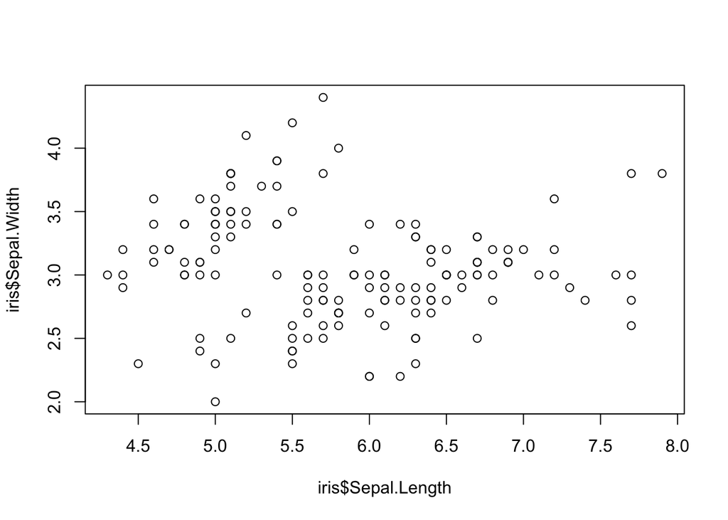

```r
# Create a simple scatter plot
plot(
  x = iris$Sepal.Length
  , y = iris$Sepal.Width
  , type = "p"
)
```

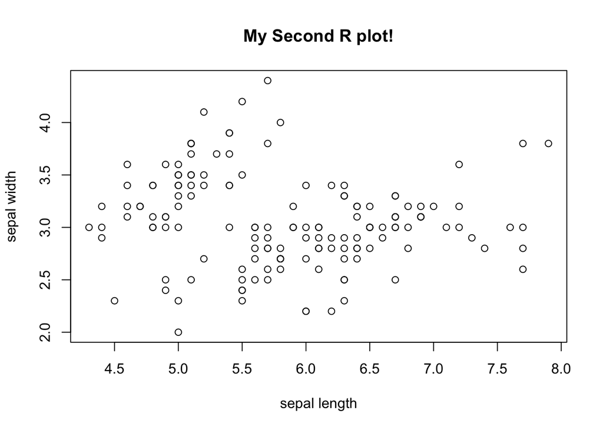

```r
# Try again, but with labels!
plot(
  x = iris$Sepal.Length
  , y = iris$Sepal.Width
  , main = "My Second R plot!"
  , xlab = "sepal length"
  , ylab = "sepal width"
  , type = "p"
)
```

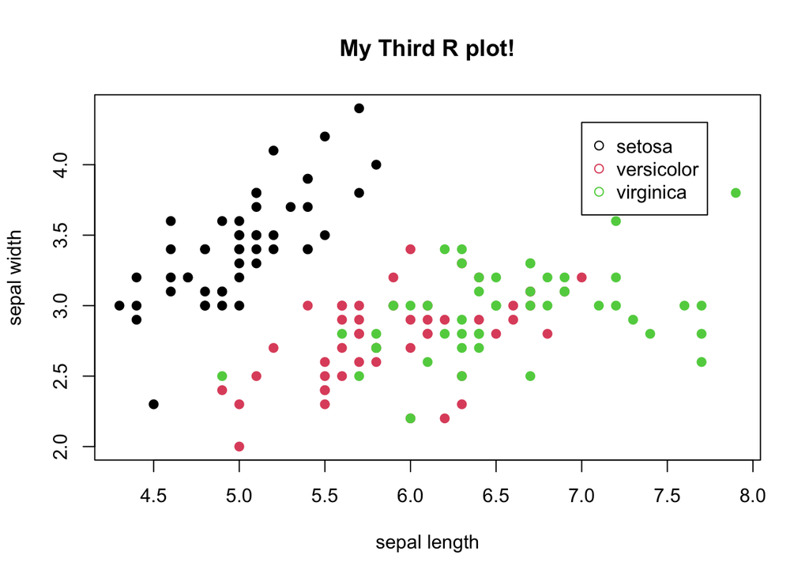

```r
# Try it AGAIN, this time coloring by species and a legend
plot(
  x = iris$Sepal.Length
  , y = iris$Sepal.Width
  , main = "My Third R plot!"
  , xlab = "sepal length"
  , ylab = "sepal width"
  , type = "p"
  , col = iris$Species
  , bg = iris$Species
  , pch = 21
)

# Add a legend
legend(
  x = 7
  , y = 4.3
  , unique(iris$Species)
  , col = seq_along(iris$Species)
  , pch = 1
)
```

The base plotting system can be a great tool for quick exploratory analysis of data, such as examination of the distribution of variables in your data.

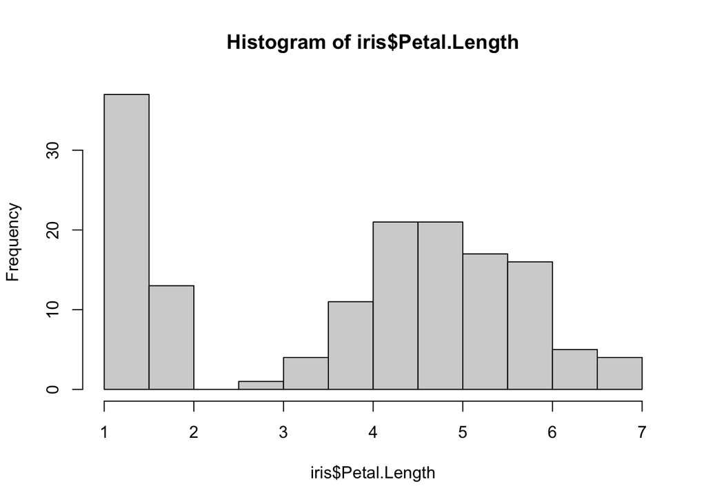

```r
# Minimal Histogram
hist(iris$Petal.Length)
```

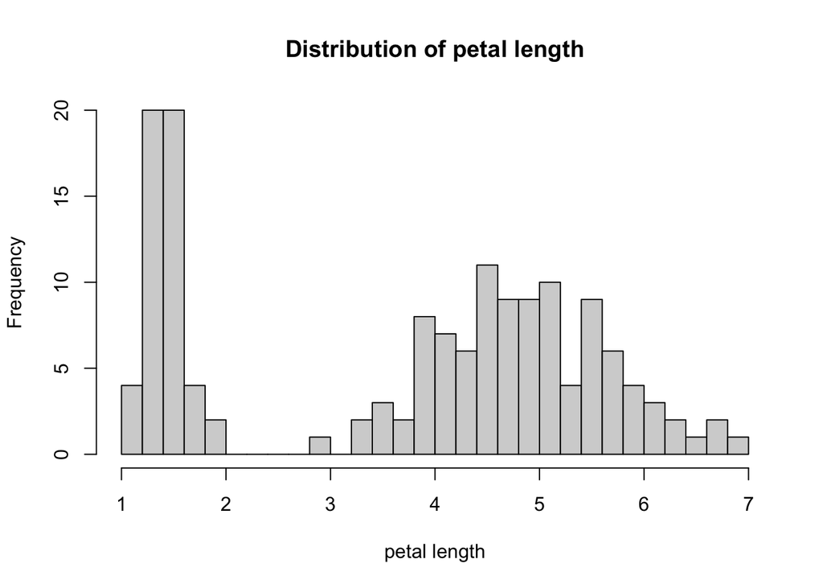

```r
# Better histogram
hist(
  iris$Petal.Length
  , main = "Distribution of petal length"
  , xlab = "petal length"
  , breaks = 25
)
```

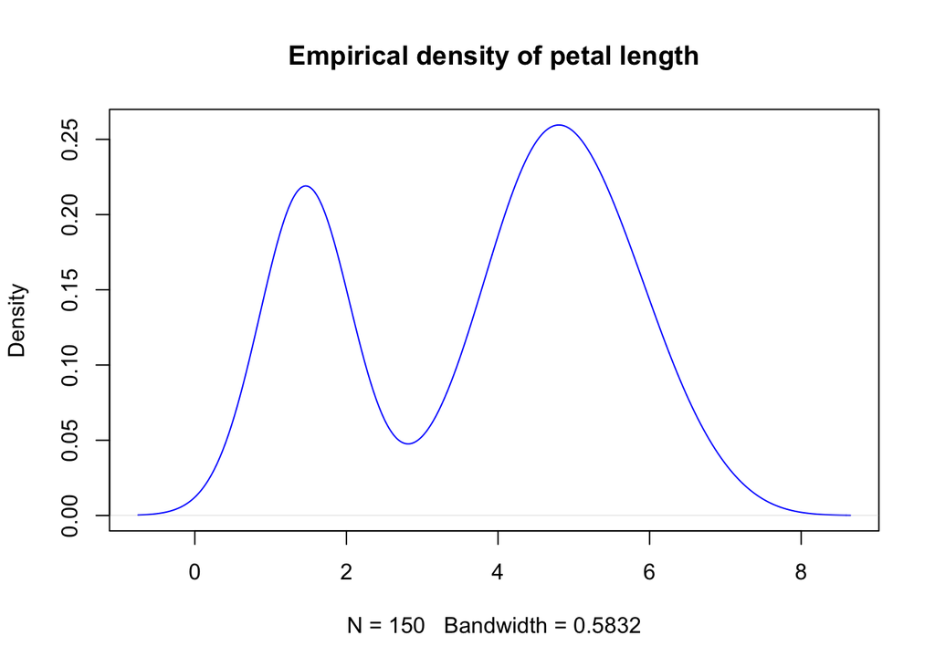

```r
# Empirical density
plot(
  density(iris$Petal.Length)
  , main = "Empirical density of petal length"
  , col = "blue"
)
```

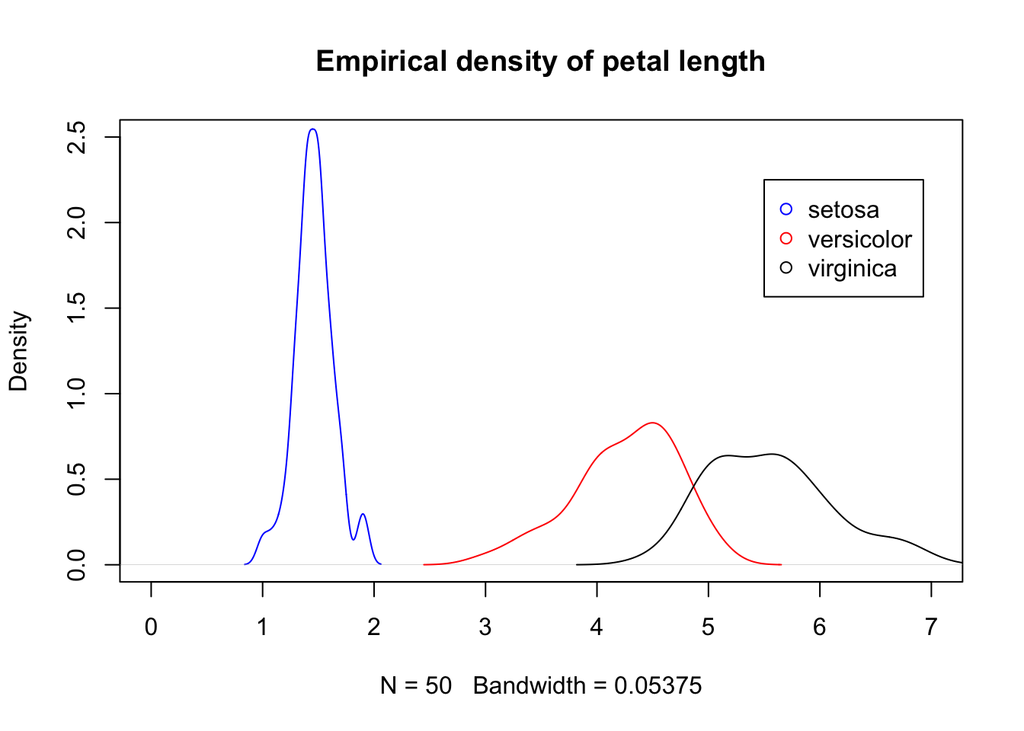

```r
# Overlay densities of Petal length by species
plot(
  density(iris[iris$Species == "setosa", "Petal.Length"])
  , main = "Empirical density of petal length"
  , col = "blue"
  , xlim = c(0, 7)
  , ylim = c(0, 2.5)
)
lines(density(iris[iris$Species == "versicolor", "Petal.Length"]), col = "red")
lines(density(iris[iris$Species == "virginica", "Petal.Length"]), col = "black")

# Add a legend
legend(
  x = 5.5
  , y = 2.25
  , legend = unique(iris$Species)
  , col = c("blue", "red", "black")
  , pch = 1
)
```

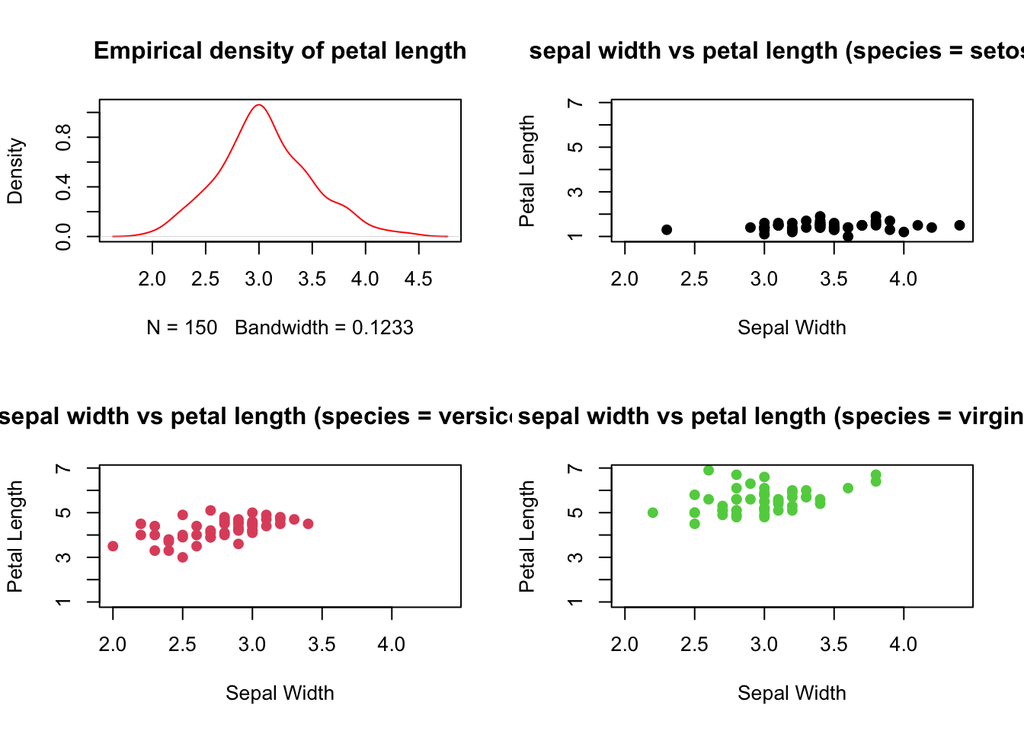

```r
par(mfrow = c(2, 2))

plot(
  density(iris$Sepal.Width)
  , main = "Empirical density of petal length"
  , col = "red"
)
plot(
    x = iris[iris$Species == "setosa", "Sepal.Width"]
    , y = iris[iris$Species == "setosa", "Petal.Length"]
    , ylab = "Petal Length"
    , xlab = "Sepal Width"
    , ylim = range(iris$Petal.Length)
    , xlim = range(iris$Sepal.Width)
    , main = "sepal width vs petal length (species = setosa)"
    , col = 1
    , bg = 1
    , pch = 21
)
plot(
    x = iris[iris$Species == "versicolor", "Sepal.Width"]
    , y = iris[iris$Species == "versicolor", "Petal.Length"]
    , ylab = "Petal Length"
    , xlab = "Sepal Width"
    , ylim = range(iris$Petal.Length)
    , xlim = range(iris$Sepal.Width)
    , main = "sepal width vs petal length (species = versicolor)"
    , col = 2
    , bg = 2
    , pch = 21
)
plot(
    x = iris[iris$Species == "virginica", "Sepal.Width"]
    , y = iris[iris$Species == "virginica", "Petal.Length"]
    , ylab = "Petal Length"
    , xlab = "Sepal Width"
    , ylim = range(iris$Petal.Length)
    , xlim = range(iris$Sepal.Width)
    , main = "sepal width vs petal length (species = virginica)"
    , col = 3
    , bg = 3
    , pch = 21
)
```

```r
# reset options
par(mfrow = c(1, 1))
```

### A Note On Graphics Devices

When R creates plots, it needs to know where to put them.

When you call `plot()` or other commands from within an RStudio session, the default is to just display the resulting figure in the “Plots” pane. However, you can use other **graphics devices** to tell R to put your figures elsewhere.

```r
outDir <- file.path(getwd(), "plots")

if (!dir.exists(outDir)) {
    dir.create("plots")
}

# Create 10 plots in a loop
for (i in seq_len(10)) {
    # Open a connection to a .png file
    fileName <- paste0("plot_", i, ".png")
    filePath <- file.path(outDir, fileName)
    png(filePath)

    # Write out a plot to that file
    plot(x = rnorm(100), y = rnorm(100))

    # Close the connection to that file
    dev.off()
}
```

# Manipulating Data Frames

## Columnwise combination with cbind

In situations where you have multiple data frames with the same rows but different columns, you can combine them column-wise with R’s `cbind()` command. Note that this command will only work if the two data frames to be joined have the same number of rows AND those rows refer to the same observation.

**cbind = “column-wise bind”**

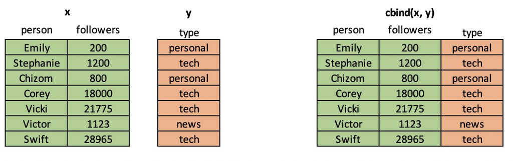

```r
x <- data.frame(
    person = c(
        "Emily", "Stephanie", "Chizom", "Corey",
        "Vicki", "Victor", "Swift"
    )
    , followers = c(200, 1200, 800, 18000, 21775, 1123, 28965)
)

y <- data.frame(
    type = c(
        "personal", "tech", "personal", "tech",
        "tech", "news", "tech"
    )
)

cbind(x, y)
```

```
##      person followers     type
## 1     Emily       200 personal
## 2 Stephanie      1200     tech
## 3    Chizom       800 personal
## 4     Corey     18000     tech
## 5     Vicki     21775     tech
## 6    Victor      1123     news
## 7     Swift     28965     tech
```

## Column Matching with merge

`cbind()` works in the limited situation where you have two data frames that can just be jammed together (same number of rows + rows line up). This doesn’t happen too often. However, it is VERY common in data science workflows to have two mismatched tables of data from different sources and to want to combine them by matching on one or more keys. Think `JOIN` in SQL or `VLOOKUP()` in Excel. To perform this operation in R, you can use the `merge()` command.

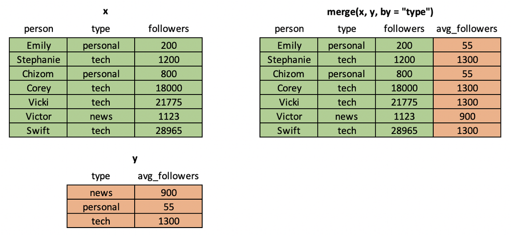

```r
x <- data.frame(
    person = c(
        "Emily", "Stephanie", "Chizom", "Corey",
        "Vicki", "Victor", "Swift"
    )
    , followers = c(200, 1200, 800, 18000, 21775, 1123, 28965)
    , type = c(
        "personal", "tech", "personal", "tech",
        "tech", "news", "tech"
    )
)

y <- data.frame(
    type = c("news", "personal", "tech")
    , avg_followers = c(900, 55, 1300)
)

merge(x, y)
```

```
##       type    person followers avg_followers
## 1     news    Victor      1123           900
## 2 personal     Emily       200            55
## 3 personal    Chizom       800            55
## 4     tech Stephanie      1200          1300
## 5     tech     Corey     18000          1300
## 6     tech     Vicki     21775          1300
## 7     tech     Swift     28965          1300
```

## Rowwise combination with rbind

So far we’ve talked about merging columns from different tables. But what if you want to merge rows? For example, imagine that you are a researcher in a lab studying some natural phenomenon. You may take multiple samples (measuring the same variables) and then want to put them together into a single data frame to build a model. For this case, we can use R’s `rbind()` function.

**rbind = “row-wise bind”**

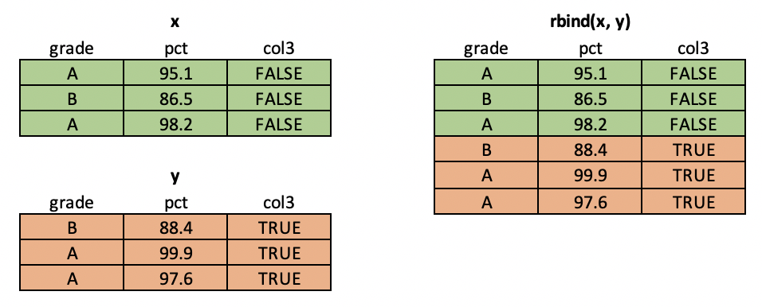

```r
x <- data.frame(
    grade = c("A", "B", "A")
    , pct = c(95.1, 86.5, 98.3)
    , col3 = rep(FALSE, 3)
)

y <- data.frame(
    grade = c("B", "A", "A")
    , pct = c(88.4, 99.9, 97.6)
    , col3 = rep(TRUE, 3)
)

fullDF <- rbind(x, y)
print(fullDF)
```

```
##   grade  pct  col3
## 1     A 95.1 FALSE
## 2     B 86.5 FALSE
## 3     A 98.3 FALSE
## 4     B 88.4  TRUE
## 5     A 99.9  TRUE
## 6     A 97.6  TRUE
```

```r
# compare
dim(x)
```

```
## [1] 3 3
```

```r
dim(y)
```

```
## [1] 3 3
```

```r
dim(fullDF)
```

```
## [1] 6 3
```

## Rowwise Combination of Many Tables with rbindlist

`rbind()` works as a strategy for combining two tables, but what if you have 5 tables? 10? 1000? For those situations, you should checkout `rbindlist()` from the `{data.table}` package.

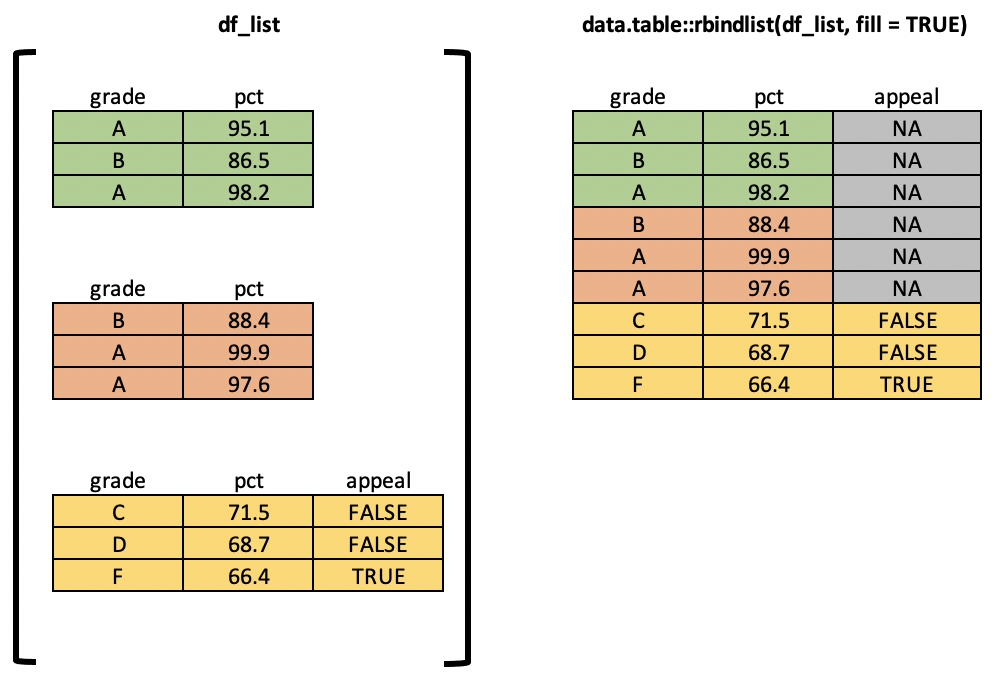

```r
library(data.table)

df1 <- data.frame(
    grade = c("A", "B", "A")
    , pct = c(95.1, 86.5, 98.3)
)

df2 <- data.frame(
    grade = c("B", "A", "A")
    , pct = c(88.4, 99.9, 97.6)
)

df3 <- data.frame(
  grade = c("C", "D", "F")
  , pct = c(71.5, 68.7, 66.4)
  , appeal = c(FALSE, FALSE, TRUE)
)

# put all the data frames in a list
df_list <- list(df1, df2, df3)
print(str(df_list, max.level = 1))
```

```
## List of 3
##  $ :'data.frame':    3 obs. of  2 variables:
##  $ :'data.frame':    3 obs. of  2 variables:
##  $ :'data.frame':    3 obs. of  3 variables:
## NULL
```

```r
# get one new big dataframe
fullDF <- data.table::rbindlist(
    l = df_list
    , fill = TRUE
)
print(fullDF)
```

```
##     grade   pct appeal
##    <char> <num> <lgcl>
## 1:      A  95.1     NA
## 2:      B  86.5     NA
## 3:      A  98.3     NA
## 4:      B  88.4     NA
## 5:      A  99.9     NA
## 6:      A  97.6     NA
## 7:      C  71.5  FALSE
## 8:      D  68.7  FALSE
## 9:      F  66.4   TRUE
```